# Assignment 1: Data set selection and initial Processing

Jeffrey Chen

23 February 2022

## Downloading the Packages/Data

First, I am downloading any packages that I will need to work on the data set, and load it into the library.

```r
# Installing packages if they are not installed
if (!requireNamespace("BiocManager", quietly = TRUE))
  install.packages("BiocManager")

if (!requireNamespace("GEOmetadb", quietly = TRUE))
  BiocManager::install("GEOmetadb")
if (!requireNamespace("edgeR", quietly = TRUE))
  BiocManager::install("edgeR")

if (!requireNamespace("GEOquery", quietly = TRUE))
    BiocManager::install("GEOquery")

if (!requireNamespace("biomaRt", quietly = TRUE))
  install.packages("knitr")

if (!requireNamespace("knitr", quietly = TRUE))
  install.packages("knitr")

BiocManager::install("SeqGSEA")
# Importing packages
library(SeqGSEA)
library(BiocManager)
library(GEOmetadb)
library(edgeR)
library(GEOquery)
library(knitr)
library(biomaRt)
```

## Getting the file using GEOmetadb. I am getting the expression data

```r
# Getting the expression data for GSE196464
supp_files = getGEOSuppFiles('GSE196464')
gse196464 <- getGEO("GSE196464",GSEMatrix=FALSE)
```

```
## Reading file....
```

```
## Parsing....
```

[output not shown]

```
## GPL18573 (1 of 20 entities)
```

```
## GSM5884657 (2 of 20 entities)
```

```
## GSM5884658 (3 of 20 entities)
```

```
## GSM5884659 (4 of 20 entities)
```

```
## GSM5884660 (5 of 20 entities)
```

```
## GSM5884661 (6 of 20 entities)
```

```
## GSM5884662 (7 of 20 entities)
```

```
## GSM5884663 (8 of 20 entities)
```

```
## GSM5884664 (9 of 20 entities)
```

```
## GSM5884665 (10 of 20 entities)
```

```
## GSM5884666 (11 of 20 entities)
```

```
## GSM5884667 (12 of 20 entities)
```

```
## GSM5884668 (13 of 20 entities)
```

```
## GSM5884669 (14 of 20 entities)
```

```
## GSM5884670 (15 of 20 entities)
```

```
## GSM5884671 (16 of 20 entities)
```

```
## GSM5884672 (17 of 20 entities)
```

```
## GSM5884673 (18 of 20 entities)
```

```
## GSM5884674 (19 of 20 entities)
```

## Here I retrieve information for the data set

```r
# Getting info for GSE196464
GSE196464_gpl_info <- Meta(getGEO(names(GPLList(gse196464))[1]))
```

Here’s a brief GEO description of the data set

```r
data.frame(head(Meta(gse196464)))
```

| contact_address | contact_city | contact_country | contact_email | contact_institute | contact_name |
| --- | --- | --- | --- | --- | --- |
| 670 Albany street, 2nd floor | Boston | USA | feiyaw@bu.edu | Center of Regenerative Medicine, Boston University | Feiya,,Wang |

## Getting more info about platform

**Platform Title:** Illumina NextSeq 500 (Homo sapiens)  
**Last Update Data::** Mar 26 2019  
**Organims:** Homo sapiens

## Grabbing the expression data from the data set

```r
fnames = rownames(supp_files)
cov_19  <- read.csv(fnames[1],header=TRUE, check.names = FALSE)
colnames(cov_19)[1] <- "hgnc_symbol" #named this for later purposes e.g. merge

raw_samples_names <- unname(
    unlist(data.frame(strsplit(colnames(cov_19)[2: length(colnames(cov_19))],
                               "/")))[c(TRUE, FALSE)])
colnames(cov_19)[2: ncol(cov_19)] <- raw_samples_names
colnames(cov_19)
```

```
##  [1] "hgnc_symbol" "HF_WR_1"     "HF_WR_3"     "HF_WR_5"     "HF_WR_7"
##  [6] "HF_WR_9"     "HF_WR_11"    "HF_WR_13"    "HF_WR_15"    "HF_WR_17"
## [11] "HF_WR_1"     "HF_WR_3"     "HF_WR_5"     "HF_WR_7"     "HF_WR_9"
## [16] "HF_WR_11"    "HF_WR_13"    "HF_WR_15"    "HF_WR_17"
```

```r
kable(cov_19[1:15,1:18], type = "html")
```

| hgnc_symbol | HF_WR_1 | HF_WR_3 | HF_WR_5 | HF_WR_7 | HF_WR_9 | HF_WR_11 | HF_WR_13 | HF_WR_15 | HF_WR_17 | HF_WR_1.1 | HF_WR_3.1 | HF_WR_5.1 | HF_WR_7.1 | HF_WR_9.1 | HF_WR_11.1 | HF_WR_13.1 | HF_WR_15.1 |
| --- | --- | --- | --- | --- | --- | --- | --- | --- | --- | --- | --- | --- | --- | --- | --- | --- | --- |
| MIR1302.2HG | 0.0322859 | 0.0000000 | 0.0000000 | 0.0336807 | 0.0000000 | 0.0000000 | 0.0000000 | 0.0000000 | 0.0000000 | 0.0000000 | 0.0000000 | 0.0000000 | 0.0000000 | 0.0000000 | 0.0000000 | 0.0605118 | 0.0000000 |
| FAM138A | 0.0000000 | 0.0000000 | 0.0000000 | 0.0000000 | 0.0000000 | 0.0000000 | 0.0000000 | 0.0000000 | 0.0000000 | 0.0000000 | 0.0000000 | 0.0000000 | 0.0000000 | 0.0000000 | 0.0000000 | 0.0000000 | 0.0000000 |
| OR4F5 | 0.0000000 | 0.0000000 | 0.0000000 | 0.0000000 | 0.0000000 | 0.0000000 | 0.0000000 | 0.0000000 | 0.0000000 | 0.0000000 | 0.0000000 | 0.0000000 | 0.0000000 | 0.0000000 | 0.0000000 | 0.0000000 | 0.0000000 |
| AL627309.1 | 0.0968578 | 0.0000000 | 0.0556133 | 0.1010421 | 0.0296994 | 0.0627348 | 0.0288104 | 0.0603533 | 0.0269422 | 0.2506904 | 0.1506809 | 0.0249658 | 0.2462006 | 0.0615898 | 0.1308050 | 0.1815355 | 0.2737856 |
| AL627309.3 | 0.0000000 | 0.0000000 | 0.0000000 | 0.0000000 | 0.0000000 | 0.0000000 | 0.0000000 | 0.0000000 | 0.0000000 | 0.0000000 | 0.0000000 | 0.0000000 | 0.0000000 | 0.0000000 | 0.0000000 | 0.0000000 | 0.0000000 |
| AL627309.2 | 0.0968578 | 0.0881554 | 0.0834200 | 0.0673614 | 0.0000000 | 0.0000000 | 0.1728624 | 0.1207065 | 0.1347108 | 0.0940089 | 0.1205447 | 0.0499315 | 0.1367781 | 0.2463592 | 0.0327012 | 0.2420474 | 0.1216825 |
| AL627309.4 | 0.0000000 | 0.0000000 | 0.0000000 | 0.0000000 | 0.0000000 | 0.0000000 | 0.0000000 | 0.0000000 | 0.0000000 | 0.0000000 | 0.0000000 | 0.0000000 | 0.0000000 | 0.0000000 | 0.0000000 | 0.0000000 | 0.0000000 |
| AL732372.1 | 0.0000000 | 0.0293851 | 0.0000000 | 0.0000000 | 0.0296994 | 0.0000000 | 0.0000000 | 0.0000000 | 0.0000000 | 0.0000000 | 0.0000000 | 0.0000000 | 0.0273556 | 0.0307949 | 0.0327012 | 0.0302559 | 0.0000000 |
| OR4F29 | 0.0000000 | 0.0000000 | 0.0000000 | 0.0000000 | 0.0000000 | 0.0000000 | 0.0000000 | 0.0000000 | 0.0000000 | 0.0000000 | 0.0000000 | 0.0000000 | 0.0000000 | 0.0000000 | 0.0000000 | 0.0000000 | 0.0000000 |
| AC114498.1 | 0.0000000 | 0.0293851 | 0.0000000 | 0.0336807 | 0.0000000 | 0.0000000 | 0.0000000 | 0.0301766 | 0.0000000 | 0.0313363 | 0.0000000 | 0.0000000 | 0.0000000 | 0.0307949 | 0.0000000 | 0.0000000 | 0.0000000 |
| OR4F16 | 0.0000000 | 0.0000000 | 0.0000000 | 0.0000000 | 0.0000000 | 0.0000000 | 0.0000000 | 0.0000000 | 0.0000000 | 0.0000000 | 0.0000000 | 0.0000000 | 0.0000000 | 0.0000000 | 0.0000000 | 0.0000000 | 0.0000000 |
| AL669831.2 | 0.0000000 | 0.0000000 | 0.0000000 | 0.0336807 | 0.0000000 | 0.0000000 | 0.0288104 | 0.0000000 | 0.0000000 | 0.0313363 | 0.0000000 | 0.0000000 | 0.0000000 | 0.0000000 | 0.0000000 | 0.0000000 | 0.0000000 |
| AL669831.5 | 0.8717200 | 1.0284796 | 0.9732331 | 0.6736137 | 1.0097801 | 0.6587158 | 0.9507430 | 1.4183016 | 1.1046283 | 1.0654343 | 1.6273540 | 0.9486994 | 1.3130699 | 1.2010012 | 1.3407509 | 1.1497250 | 1.2776661 |
| FAM87B | 0.4520030 | 0.1763108 | 0.2780666 | 0.1684034 | 0.2672947 | 0.0313674 | 0.4033455 | 0.4224728 | 0.6196695 | 0.2506904 | 0.3917704 | 0.3994524 | 0.5197568 | 0.2771541 | 0.3270124 | 0.2420474 | 0.3346268 |
| LINC00115 | 0.2905733 | 0.3526216 | 0.1946466 | 0.5388910 | 0.1781965 | 0.1882045 | 0.3169143 | 0.6337092 | 0.2694215 | 0.3446993 | 0.3917704 | 0.4993155 | 0.4376900 | 0.6774879 | 0.4578174 | 0.3630710 | 0.2433650 |

## Cleaning Data

How many genes do we have measurements for?

```r
dim(cov_19)
```

```
## [1] 33551    19
```

```r
summarized_gene_counts <- sort(table(cov_19$gname),
                               decreasing = TRUE)
kable(summarized_gene_counts[which(summarized_gene_counts>1)], format="html")
```

| x |
| --- |

## Filtering out low counts

```r
cpms = cpm(cov_19[,2:19])
rownames(cpms) <- cov_19[,1]
# get rid of low counts
keep = rowSums(cpms >1) >= 3
cov_19_filtered = cov_19[keep,]
dim(cov_19_filtered)
```

```
## [1] 16131    19
```

In this step we have filtered our set from 33551 to 16131.

## Box plot

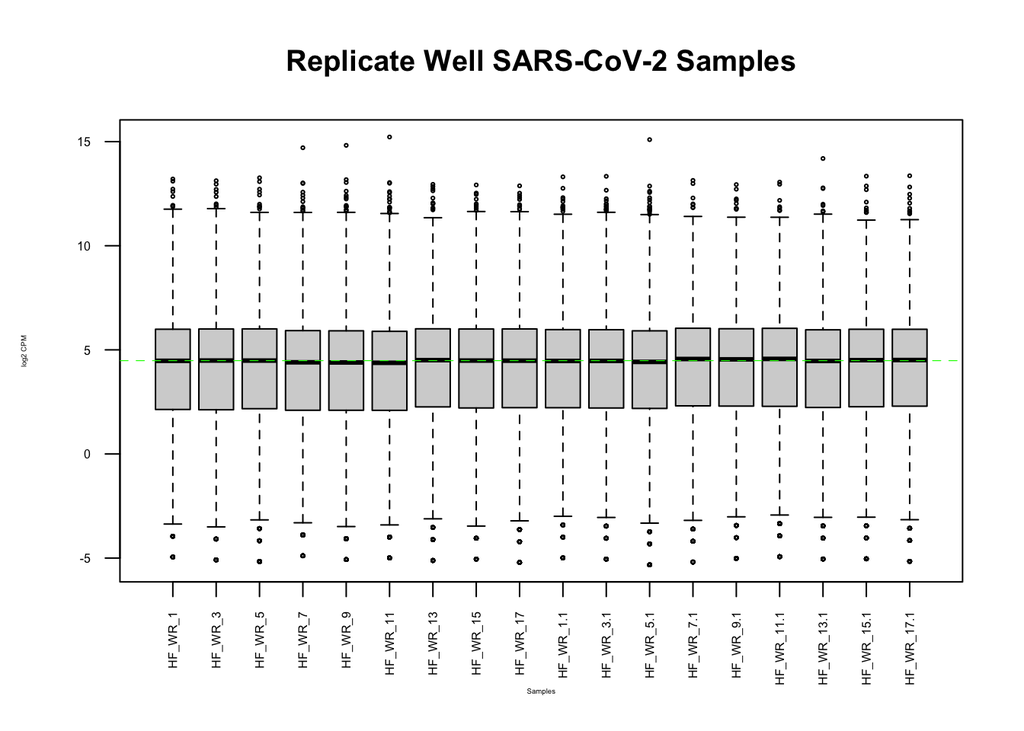

```r
data2plot <- log2(cpm(cov_19_filtered[, 2: ncol(cov_19_filtered)]))
boxplot(data2plot,
        xlab = "Samples",
        ylab = "log2 CPM",
        las = 2,
        cex = 0.3,
        cex.lab = 0.3,
        cex.axis = 0.5,
        main = "Replicate Well SARS-CoV-2 Samples")
#draw the median on each box plot
abline(h = median(apply(data2plot, 2, median)),
       col = "green", lwd = 0.6, lty = "dashed")
```

## Density Plot

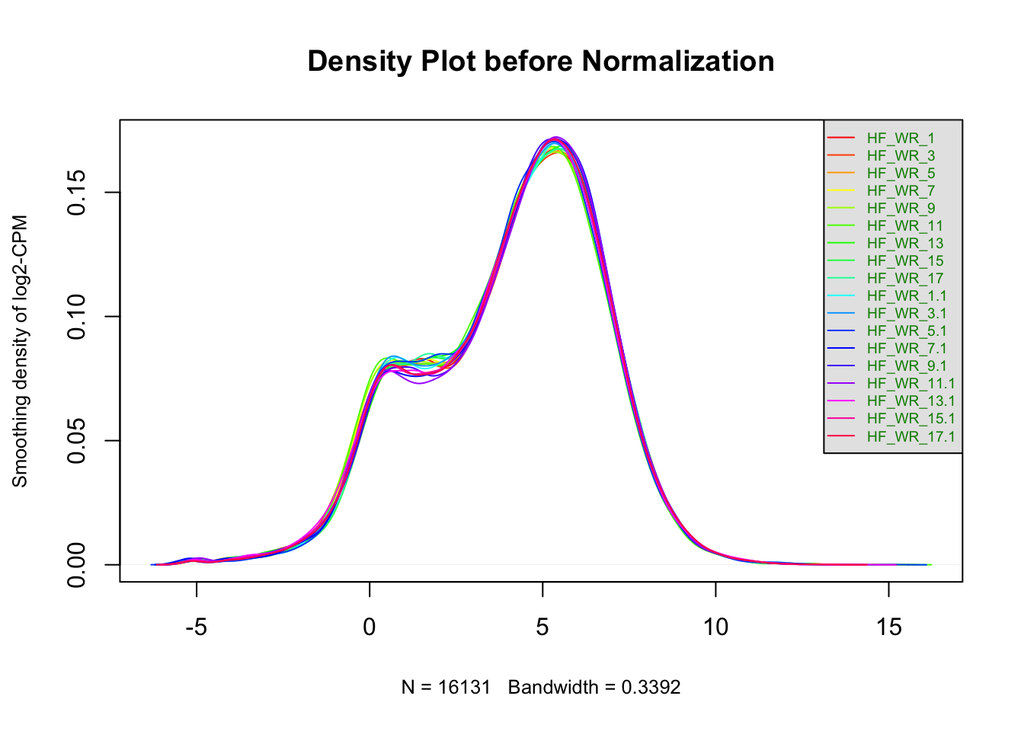

```r
counts_density <-
  apply(log2(cpm(cov_19_filtered[, 2:length(colnames(cov_19_filtered))])),
        2, density)
 #calculate the limits across all the samples
xlim <- 0; ylim <- 0
for (i in 1:length(counts_density)) {
  xlim <- range(c(xlim, counts_density[[i]]$x));
  ylim <- range(c(ylim, counts_density[[i]]$y))
}
 cols <- rainbow(length(counts_density))
 ltys <- rep(1, length(counts_density))

 #plot the first density plot to initialize the plot
 plot(counts_density[[1]],
      xlim=xlim,
      ylim=ylim,
      type="n",
      ylab="Smoothing density of log2-CPM",
      main="Density Plot before Normalization",
      cex.lab = 0.8)

 #plot each line
 for (i in 1:length(counts_density)) {
   lines(counts_density[[i]],
         col = cols[i],
         lty = ltys[i])
 }

 #create legend
 legend("topright", colnames(data2plot),
 col=cols, lty=ltys, cex=0.6,
 border ="blue", text.col = "green4",
 merge = TRUE, bg = "gray90")
```

## Regrouping geenes based on cell_types

```r
# Group them based on different cell types
cell_type <- unlist(strsplit(raw_samples_names, "_"))[c(FALSE, TRUE, FALSE)]
samples <- data.frame(cell_type = cell_type)
```

## Mapping the symbols

```r
cov_19_ensemble <- convertSymbol2Ensembl(cov_19_filtered$hgnc_symbol)
cov19_merge <- merge(cov_19_ensemble, cov_19_filtered, by = "hgnc_symbol")
httr::set_config(httr::config(ssl_verifypeer = FALSE)) # sometimes code bellow runs error, this line solves it
ensembl <- useMart("ensembl")
datasets <- listDatasets(ensembl)
ensembl <- useDataset("hsapiens_gene_ensembl", mart = ensembl)
```

```
## Ensembl site unresponsive, trying uswest mirror
```

## RDS File

```r
conversion_stash <- "./cov19_id_conversion.rds"
if (file.exists(conversion_stash)) {
  cov19_id_conversion <- readRDS(conversion_stash)
} else {
  fcol <- c(cov19_merge[,2])
  scol <- c(cov19_merge[,1])
  cov19_id_conversion <- data.frame(fcol, scol)
  colnames(cov19_id_conversion)[1] <- "ensembl_gene_id"
  colnames(cov19_id_conversion)[2] <- "hgnc_symbol"
  saveRDS(cov19_id_conversion, conversion_stash)
}
```

For some reason, getBM function was not working so I created and used convertSymbol2Ensembl and merged the two dataframes to get the conversion I needed.

## Merge new identifiers

```r
cov_19_filtered_annot <- merge(cov19_id_conversion,
                                 cov19_merge,
                                 by.x = 1,
                                 by.y = 1,
                                 all.y=TRUE)
kable(cov_19_filtered_annot[1:30,], type = "html")
```

| ensembl_gene_id | hgnc_symbol | ensembl_gene_id.y | HF_WR_1 | HF_WR_3 | HF_WR_5 | HF_WR_7 | HF_WR_9 | HF_WR_11 | HF_WR_13 | HF_WR_15 | HF_WR_17 | HF_WR_1.1 | HF_WR_3.1 | HF_WR_5.1 | HF_WR_7.1 | HF_WR_9.1 | HF_WR_11.1 | HF_WR_13.1 | HF_WR_15.1 | HF_WR_17.1 |
| --- | --- | --- | --- | --- | --- | --- | --- | --- | --- | --- | --- | --- | --- | --- | --- | --- | --- | --- | --- | --- |
| A1BG | NA | ENSG00000121410 | 7.2643334 | 5.8770261 | 8.6756778 | 7.1066249 | 6.6229693 | 7.3086084 | 7.116167 | 5.4016167 | 5.3345464 | 3.0396215 | 2.4410309 | 3.5201741 | 5.8541034 | 5.1735436 | 5.068692 | 4.235829 | 5.4148707 | 4.7309650 |
| A4GALT | NA | ENSG00000128274 | 36.4508107 | 33.2051975 | 32.7840517 | 31.6935262 | 27.5313568 | 31.5242551 | 32.757417 | 30.2973361 | 29.1783521 | 32.2137206 | 32.7278964 | 27.5871800 | 59.8814599 | 55.3692344 | 60.235686 | 54.339632 | 51.7150569 | 57.5834024 |
| AAAS | NA | ENSG00000094914 | 41.5519871 | 34.6450689 | 43.7120689 | 36.4425031 | 36.7381751 | 35.2256105 | 38.605927 | 41.4023357 | 42.6494289 | 33.7491995 | 38.5441800 | 36.4500297 | 41.3890584 | 42.7433245 | 39.535801 | 35.762497 | 40.7636331 | 38.7995118 |
| AACS | NA | ENSG00000081760 | 45.7168715 | 40.7865612 | 47.4103547 | 41.4272447 | 43.2423468 | 43.6320785 | 55.863353 | 49.8517920 | 49.8160417 | 48.1012268 | 48.9411636 | 54.9496681 | 37.8875386 | 39.1403209 | 36.363780 | 34.279957 | 36.5960079 | 39.1634321 |
| AADAC | NA | ENSG00000114771 | 0.2582874 | 0.2056959 | 0.2224533 | 0.2357648 | 0.3266936 | 0.3136742 | 0.144052 | 0.1508831 | 0.1616529 | 0.2820267 | 0.1808171 | 0.6241443 | 1.4772037 | 1.6629247 | 0.948336 | 1.724587 | 1.3689280 | 1.4836754 |
| AADACL2 | NA | ENSG00000261846 | 2.3568726 | 1.9688037 | 2.5025994 | 1.8187571 | 2.3759531 | 1.6624732 | 2.679367 | 1.5088315 | 1.8320664 | 2.1935413 | 1.6876263 | 2.7961667 | 3.2006080 | 3.2334647 | 2.387191 | 2.390218 | 2.6770147 | 2.7993876 |
| AADACL2 | NA | ENSG00000197953 | 2.3568726 | 1.9688037 | 2.5025994 | 1.8187571 | 2.3759531 | 1.6624732 | 2.679367 | 1.5088315 | 1.8320664 | 2.1935413 | 1.6876263 | 2.7961667 | 3.2006080 | 3.2334647 | 2.387191 | 2.390218 | 2.6770147 | 2.7993876 |
| AADAT | NA | ENSG00000109576 | 14.6255246 | 13.9579370 | 16.6561891 | 13.0007451 | 14.5824123 | 12.0450885 | 19.504636 | 14.5149588 | 16.4616557 | 11.8137867 | 10.1257580 | 13.9309018 | 9.0273558 | 8.1606491 | 9.254451 | 6.111696 | 6.0537037 | 7.3623893 |
| AAGAB | NA | ENSG00000103591 | 58.7603857 | 62.3258619 | 59.3950250 | 53.8217374 | 60.0819146 | 50.5956453 | 60.617068 | 65.6039926 | 67.8942266 | 65.6182208 | 69.7351310 | 58.3699791 | 61.2492411 | 65.2851930 | 67.429959 | 63.718967 | 68.7506050 | 58.0592982 |
| AAK1 | NA | ENSG00000115977 | 55.4349353 | 68.7024352 | 62.7040175 | 57.6276550 | 57.0822737 | 56.9945986 | 60.127291 | 53.9558136 | 62.9907547 | 65.3361940 | 62.4723105 | 47.4349702 | 81.6565362 | 67.9335546 | 79.725626 | 94.156423 | 72.4619208 | 71.6083341 |
| AAMDC | NA | ENSG00000087884 | 11.0740727 | 9.1975459 | 9.9547841 | 8.6559365 | 8.5534312 | 9.1906535 | 9.536240 | 9.5358149 | 10.1302497 | 9.2128734 | 7.9860889 | 8.2886369 | 10.0942251 | 11.0861648 | 9.712269 | 8.955752 | 11.0731063 | 9.4899239 |
| AAMP | NA | ENSG00000127837 | 89.3674438 | 84.0414734 | 85.8113516 | 80.6652448 | 74.7534251 | 76.3482955 | 92.394932 | 90.2582990 | 89.4748915 | 78.1214061 | 77.1184962 | 77.6185907 | 89.8085120 | 95.7413514 | 97.286193 | 85.836045 | 89.4366277 | 88.9925309 |
| AAR2 | NA | ENSG00000131043 | 46.2657323 | 41.9913515 | 38.8180968 | 37.1161168 | 36.0253892 | 36.0725308 | 39.585481 | 42.3378113 | 42.5147181 | 44.5288881 | 42.8837906 | 40.9189032 | 39.0091191 | 38.4628330 | 37.475623 | 38.485530 | 38.7254514 | 35.4682405 |
| AARS2 | NA | ENSG00000124608 | 25.8610269 | 26.8286242 | 27.9456929 | 27.5508018 | 22.6606529 | 24.8116277 | 24.431214 | 24.5939531 | 23.8168636 | 22.6561479 | 22.0596871 | 19.8228244 | 25.0030399 | 25.7445384 | 25.016450 | 22.480149 | 21.7203239 | 22.5070761 |
| AARSD1 | NA | ENSG00000266967 | 3.3577363 | 2.2626551 | 3.4758325 | 3.4354300 | 3.4748314 | 3.1994766 | 5.848510 | 5.2809102 | 5.9811581 | 4.8257908 | 5.1231514 | 4.6436339 | 3.0364742 | 3.0179004 | 2.517996 | 2.813801 | 2.4032291 | 3.3312712 |
| AASDH | NA | ENSG00000157426 | 19.5975572 | 19.4529564 | 18.7138819 | 16.9413854 | 17.1959607 | 15.2759326 | 15.701664 | 16.0539669 | 15.7611597 | 13.6312923 | 12.4161080 | 14.9794643 | 16.8784197 | 18.8156853 | 15.565791 | 13.403373 | 17.4614368 | 16.3764173 |
| AASDHPPT | NA | ENSG00000149313 | 59.1801028 | 61.2679972 | 55.1962194 | 51.9019383 | 53.9341358 | 49.3409486 | 57.217441 | 55.1327022 | 54.4500921 | 52.3002915 | 49.9356577 | 48.5584300 | 49.1306998 | 52.8748473 | 50.294509 | 47.864865 | 49.4030896 | 47.8415336 |
| AASS | NA | ENSG00000008311 | 1.9694415 | 1.9688037 | 2.3635661 | 1.1451433 | 1.4552713 | 1.1292270 | 2.938660 | 1.7804211 | 2.1553723 | 0.6580624 | 0.7835408 | 0.8738021 | 24.3191493 | 19.9243018 | 22.073338 | 20.301722 | 21.2335939 | 20.5195109 |
| AATBC | NA | ENSG00000215458 | 1.0008637 | 1.3517160 | 1.6683996 | 1.4145888 | 1.2176760 | 1.7565754 | 1.267657 | 1.4786548 | 1.6165292 | 1.2221159 | 0.8136770 | 2.3717485 | 6.8115503 | 4.3112863 | 6.671053 | 6.051184 | 4.5326726 | 5.3188364 |
| AATF | NA | ENSG00000276072 | 53.7883531 | 56.4194506 | 53.6112398 | 53.6870147 | 51.1720903 | 47.4589035 | 46.327113 | 54.7102294 | 53.9651333 | 52.8956813 | 54.6670387 | 47.4849018 | 52.5227972 | 52.2589493 | 54.839982 | 45.262856 | 50.2852876 | 48.9053009 |
| AATF | NA | ENSG00000275700 | 53.7883531 | 56.4194506 | 53.6112398 | 53.6870147 | 51.1720903 | 47.4589035 | 46.327113 | 54.7102294 | 53.9651333 | 52.8956813 | 54.6670387 | 47.4849018 | 52.5227972 | 52.2589493 | 54.839982 | 45.262856 | 50.2852876 | 48.9053009 |
| AATK | NA | ENSG00000181409 | 1.1622933 | 1.2635606 | 1.8908529 | 1.5829923 | 1.4255719 | 1.2233293 | 2.506504 | 2.5046603 | 2.3709095 | 1.8488419 | 2.2300777 | 2.6463720 | 0.7933131 | 0.6466929 | 1.209946 | 0.756398 | 0.6388331 | 0.6158653 |
| ABALON | NA | ENSG00000281376 | 3.2285926 | 4.2314588 | 3.8651257 | 2.7954970 | 3.1481379 | 3.7640902 | 5.560406 | 5.3714401 | 4.9304141 | 4.1050558 | 4.7313810 | 3.6949345 | 6.3465047 | 6.6824938 | 7.717493 | 5.990672 | 6.5708543 | 6.5785608 |
| ABAT | NA | ENSG00000183044 | 111.8384485 | 109.4596113 | 104.6086535 | 109.5632740 | 110.9570108 | 113.6127882 | 91.098464 | 83.9513834 | 90.7411727 | 98.6780216 | 92.3975417 | 117.6137604 | 72.4376911 | 69.0113762 | 72.335146 | 85.957069 | 72.0968734 | 73.7638625 |
| ABCA1 | NA | ENSG00000165029 | 43.3599989 | 40.6984058 | 37.9560904 | 37.1497975 | 36.7084757 | 39.5229467 | 44.973024 | 38.3243195 | 35.2133945 | 37.6975738 | 35.5908339 | 39.2212306 | 82.0668706 | 66.3014247 | 69.947955 | 76.940805 | 69.3590174 | 68.7529588 |
| ABCA10 | NA | ENSG00000154263 | 1.5820104 | 2.1157294 | 1.3625263 | 2.3576481 | 2.2868549 | 1.9134125 | 2.160779 | 1.6898913 | 1.8051243 | 1.8175056 | 2.1095329 | 1.4729807 | 5.2796353 | 4.2496965 | 3.891448 | 5.597345 | 5.0802438 | 4.7589589 |
| ABCA12 | NA | ENSG00000144452 | 7.1351897 | 7.7282893 | 6.1730784 | 11.3503914 | 12.8895457 | 11.9823537 | 9.392188 | 17.5024451 | 12.3125641 | 13.4119381 | 16.5146291 | 17.2763155 | 86.5258372 | 59.3109819 | 93.721757 | 85.321694 | 66.4690584 | 46.6098031 |
| ABCA13 | NA | ENSG00000179869 | 36.9350996 | 43.2255270 | 29.0579593 | 55.5394524 | 73.6842462 | 60.3195449 | 51.858708 | 78.4290602 | 65.1730691 | 67.5924079 | 82.8142350 | 147.9971071 | 298.6139863 | 302.1287869 | 248.169720 | 363.948462 | 420.8693009 | 389.0308909 |
| ABCA2 | NA | ENSG00000107331 | 73.6441977 | 68.3791988 | 79.8329198 | 67.4287349 | 58.0029556 | 61.7310787 | 75.857766 | 78.1876472 | 74.0639798 | 47.9132090 | 43.3056972 | 50.2061711 | 67.2674782 | 66.5477840 | 64.127134 | 57.788807 | 61.9363857 | 60.6067409 |
| ABCA3 | NA | ENSG00000167972 | 25.5381676 | 22.0682330 | 24.6088938 | 22.1955726 | 21.3241793 | 20.0751476 | 23.019504 | 23.8697140 | 24.2479381 | 16.3262144 | 14.6160495 | 16.1278899 | 3.9392098 | 4.6500303 | 3.956850 | 2.632265 | 3.5287921 | 3.3592651 |

## Check duplicated mapping

```r
summarized_mapping_counts <- sort(table(cov_19_filtered_annot$hgnc_symbol),
                                  decreasing = TRUE)
head(summarized_mapping_counts)
```

```
## integer(0)
```

```r
summarized_mapping_counts_2 <- sort(table(
  cov_19_filtered_annot$ensembl_gene_id), decreasing = TRUE)
head(summarized_mapping_counts_2)
```

```
##
##  CNOT3  LENG1 MBOAT7 NDUFA3  RDH13   RPS9
##     10     10     10     10     10     10
```

## Applying TMM

```r
filtered_data_matrix <- as.matrix(cov_19_filtered_annot[,4: 12])
rownames(filtered_data_matrix) <- cov_19_filtered_annot$hgnc_symbol
d = DGEList(counts = filtered_data_matrix, group = samples$cell_type)
d = calcNormFactors(d)
normalized_counts <- cpm(d)
kable(normalized_counts[1: 10, ], type = "html")
```

|  | HF_WR_1 | HF_WR_3 | HF_WR_5 | HF_WR_7 | HF_WR_9 | HF_WR_11 | HF_WR_13 | HF_WR_15 | HF_WR_17 |
| --- | --- | --- | --- | --- | --- | --- | --- | --- | --- |
| NA | 7.1932598 | 5.8181106 | 8.5367981 | 7.4853344 | 7.0351171 | 7.8775826 | 6.9716474 | 5.327218 | 5.2623516 |
| NA | 36.0941791 | 32.8723250 | 32.2592466 | 33.3824630 | 29.2446346 | 33.9784141 | 32.0921583 | 29.880041 | 28.7834683 |
| NA | 41.1454460 | 34.2977621 | 43.0123288 | 38.3845111 | 39.0243938 | 37.9679195 | 37.8218928 | 40.832087 | 42.0722349 |
| NA | 45.2695816 | 40.3776877 | 46.6514126 | 43.6348878 | 45.9333204 | 47.0288299 | 54.7288434 | 49.165166 | 49.1418587 |
| NA | 0.2557603 | 0.2036339 | 0.2188923 | 0.2483286 | 0.3470237 | 0.3380937 | 0.1411265 | 0.148805 | 0.1594652 |
| NA | 2.3338132 | 1.9490671 | 2.4625379 | 1.9156780 | 2.5238088 | 1.7918965 | 2.6249523 | 1.488050 | 1.8072722 |
| NA | 2.3338132 | 1.9490671 | 2.4625379 | 1.9156780 | 2.5238088 | 1.7918965 | 2.6249523 | 1.488050 | 1.8072722 |
| NA | 14.4824297 | 13.8180127 | 16.3895578 | 13.6935502 | 15.4898766 | 12.9827970 | 19.1085235 | 14.315039 | 16.2388727 |
| NA | 58.1854792 | 61.7010631 | 58.4442330 | 56.6898787 | 63.8208154 | 54.5345094 | 59.3860168 | 64.700407 | 66.9753834 |
| NA | 54.8925648 | 68.0137131 | 61.7002553 | 60.6986123 | 60.6345068 | 61.4316203 | 58.9061868 | 53.212662 | 62.1382723 |

```r
nrow(normalized_counts)
```

```
## [1] 15295
```

## MDS plot

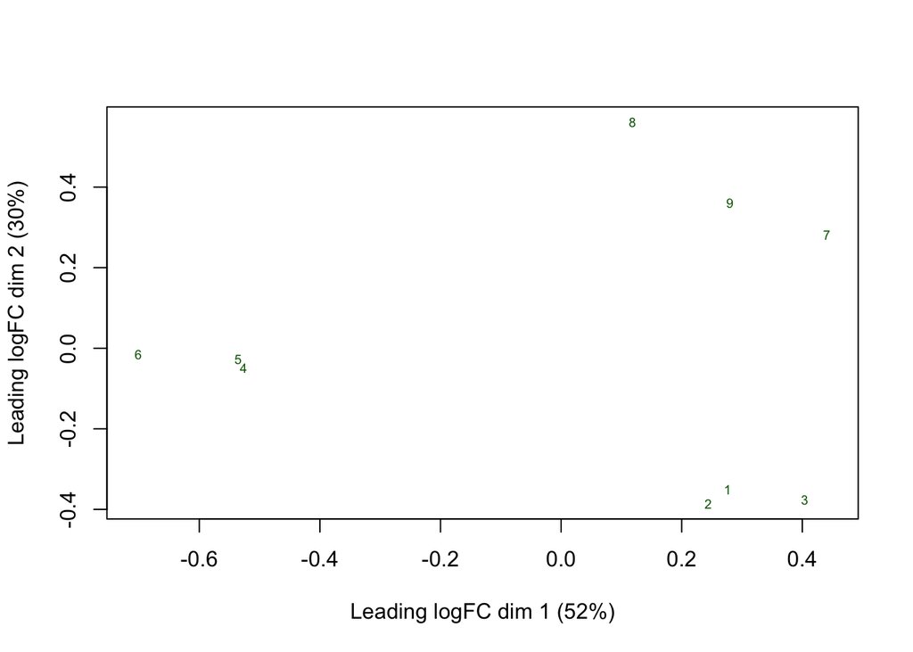

```r
plotMDS(d, labels=rownames(samples),
 col = c("darkgreen","blue")[factor(samples$cell_type)], cex = 0.6)
```

[figure not shown]

```r
# density plot after normalized by defined groups
counts_density <- apply(log2(normalized_counts), 2, density)
xlim <- 0; ylim <- 0
for (i in 1:length(counts_density)) {
  xlim <- range(c(xlim, counts_density[[i]]$x));
  ylim <- range(c(ylim, counts_density[[i]]$y))
}
 cols <- rainbow(length(counts_density))
 ltys <- rep(1, length(counts_density))

 #plot the first density plot to initialize the plot
 plot(counts_density[[1]],
      xlim=xlim,
      ylim=ylim,
      type="n",
      ylab="Smoothing density of log2-CPM",
      main="Density Plot after Normalization",
      cex.lab = 0.8)
 #plot each line
 for (i in 1:length(counts_density)) {
   lines(counts_density[[i]],
         col = cols[i],
         lty = ltys[i])
 }

 #create legend
 legend("topright", colnames(data2plot),
        col=cols, lty=ltys, cex=0.5,
        border ="blue", text.col = "green4",
        merge = TRUE, bg = "gray90")
```

## Dispersion

```r
#model_design <- model.matrix(~samples$cell_type+0)
#d <- estimateDisp(d, model_design)
```

```r
#plotBCV(d,col.tagwise = "black",col.common = "red")
```

```r
#plotMeanVar(d, show.raw.vars = TRUE,
#            show.tagwise.vars=TRUE,
#            show.ave.raw.vars = TRUE,
#            NBline=TRUE,
#            show.binned.common.disp.vars = TRUE)
```

I was unable to figure out why dispersion was not working, thus the BCV and mean variance plot were unsuccessful.

## Intepretation

**What are the control and test conditions of the dataset?**  
The controls of the data set were the BU3 NGPT Mock 1 DPI replicates, BU3 NGPT Mock 3 DPI replicates, and the 1566 Mock 1 DPI replicates. The test conditions were where the replicates were infected with SARS-CoV-2.

**Why is the dataset of interest to you?**  
This data set is interesting to me as it is quite relevant to recent times, and if studied further, we may be able to potentially what genes are causing people to be asymptomatic or not.

**Were there expression values that could not be mapped to current HUGO symbols?**  
Yes, but I removed the using the convertSymbol2Ensembl and merged/joined the associated data.

**How many outliers were removed?**  
There were none

**What is the final coverage of your dataset?**  
There were 33551 at the start and ended with 15295

## Final Result

```r
final_result <- cov_19_filtered_annot[,2:ncol(cov_19_filtered_annot)]
colnames(final_result)[1] <- "hgnc_symbol"
kable(final_result[1:10, ], type = "html")
```

| hgnc_symbol | ensembl_gene_id.y | HF_WR_1 | HF_WR_3 | HF_WR_5 | HF_WR_7 | HF_WR_9 | HF_WR_11 | HF_WR_13 | HF_WR_15 | HF_WR_17 | HF_WR_1.1 | HF_WR_3.1 | HF_WR_5.1 | HF_WR_7.1 | HF_WR_9.1 | HF_WR_11.1 | HF_WR_13.1 | HF_WR_15.1 | HF_WR_17.1 |
| --- | --- | --- | --- | --- | --- | --- | --- | --- | --- | --- | --- | --- | --- | --- | --- | --- | --- | --- | --- |
| NA | ENSG00000121410 | 7.2643334 | 5.8770261 | 8.6756778 | 7.1066249 | 6.6229693 | 7.3086084 | 7.116167 | 5.4016167 | 5.3345464 | 3.0396215 | 2.4410309 | 3.5201741 | 5.854103 | 5.173544 | 5.068692 | 4.235829 | 5.414871 | 4.730965 |
| NA | ENSG00000128274 | 36.4508107 | 33.2051975 | 32.7840517 | 31.6935262 | 27.5313568 | 31.5242551 | 32.757417 | 30.2973361 | 29.1783521 | 32.2137206 | 32.7278964 | 27.5871800 | 59.881460 | 55.369234 | 60.235686 | 54.339632 | 51.715057 | 57.583402 |
| NA | ENSG00000094914 | 41.5519871 | 34.6450689 | 43.7120689 | 36.4425031 | 36.7381751 | 35.2256105 | 38.605927 | 41.4023357 | 42.6494289 | 33.7491995 | 38.5441800 | 36.4500297 | 41.389058 | 42.743324 | 39.535801 | 35.762497 | 40.763633 | 38.799512 |
| NA | ENSG00000081760 | 45.7168715 | 40.7865612 | 47.4103547 | 41.4272447 | 43.2423468 | 43.6320785 | 55.863353 | 49.8517920 | 49.8160417 | 48.1012268 | 48.9411636 | 54.9496681 | 37.887539 | 39.140321 | 36.363780 | 34.279957 | 36.596008 | 39.163432 |
| NA | ENSG00000114771 | 0.2582874 | 0.2056959 | 0.2224533 | 0.2357648 | 0.3266936 | 0.3136742 | 0.144052 | 0.1508831 | 0.1616529 | 0.2820267 | 0.1808171 | 0.6241443 | 1.477204 | 1.662925 | 0.948336 | 1.724587 | 1.368928 | 1.483675 |
| NA | ENSG00000261846 | 2.3568726 | 1.9688037 | 2.5025994 | 1.8187571 | 2.3759531 | 1.6624732 | 2.679367 | 1.5088315 | 1.8320664 | 2.1935413 | 1.6876263 | 2.7961667 | 3.200608 | 3.233465 | 2.387191 | 2.390218 | 2.677015 | 2.799388 |
| NA | ENSG00000197953 | 2.3568726 | 1.9688037 | 2.5025994 | 1.8187571 | 2.3759531 | 1.6624732 | 2.679367 | 1.5088315 | 1.8320664 | 2.1935413 | 1.6876263 | 2.7961667 | 3.200608 | 3.233465 | 2.387191 | 2.390218 | 2.677015 | 2.799388 |
| NA | ENSG00000109576 | 14.6255246 | 13.9579370 | 16.6561891 | 13.0007451 | 14.5824123 | 12.0450885 | 19.504636 | 14.5149588 | 16.4616557 | 11.8137867 | 10.1257580 | 13.9309018 | 9.027356 | 8.160649 | 9.254451 | 6.111696 | 6.053704 | 7.362389 |
| NA | ENSG00000103591 | 58.7603857 | 62.3258619 | 59.3950250 | 53.8217374 | 60.0819146 | 50.5956453 | 60.617068 | 65.6039926 | 67.8942266 | 65.6182208 | 69.7351310 | 58.3699791 | 61.249241 | 65.285193 | 67.429959 | 63.718967 | 68.750605 | 58.059298 |
| NA | ENSG00000115977 | 55.4349353 | 68.7024352 | 62.7040175 | 57.6276550 | 57.0822737 | 56.9945986 | 60.127291 | 53.9558136 | 62.9907547 | 65.3361940 | 62.4723105 | 47.4349702 | 81.656536 | 67.933555 | 79.725626 | 94.156423 | 72.461921 | 71.608334 |

The symbols of the first column don’t show in the .html file but do when I run the chunk of code. Couldn’t find a way to fix it.

## References

Huang, J., Hume, A. J., Abo, K. M., Werder, R. B., Villacorta-Martin, C., Alysandratos, K.-D., Beermann, M. L., Simone-Roach, C., Lindstrom-Vautrin, J., Olejnik, J., Suder, E. L., Bullitt, E., Hinds, A., Sharma, A., Bosmann, M., Wang, R., Hawkins, F., Burks, E. J., Saeed, M., … Kotton, D. N. (2020, August 6). SARS-COV-2 infection of pluripotent stem cell-derived human lung alveolar type 2 cells elicits a rapid epithelial-intrinsic inflammatory response. bioRxiv : the preprint server for biology. Retrieved February 21, 2022, from https://www.ncbi.nlm.nih.gov/pmc/articles/PMC7337394.1/

Robinson MD, McCarthy DJ and Smyth GK , 2010. edgeR: a Bioconductor package for differential expression analysis of digital gene expression data. Bioinformatics 26, 139-140

Wang X, Cairns MJ (2013). “Gene Set Enrichment Analysis of RNA-Seq Data: Integrating Differential Expression and Splicing.” BMC Bioinformatics, 14(Suppl 5), S16.

Wang X, Cairns MJ (2014). “SeqGSEA: a Bioconductor package for gene set enrichment analysis of RNA-Seq data integrating differential expression and splicing.” Bioinformatics, 30(12), 1777-9.

Davis, S. and Meltzer, P. S, 2007, GEOquery: a bridge between the Gene Expression Omnibus (GEO) and BioConductor. Bioinformatics, 14, 1846-1847

Steffen Durinck, Paul T. Spellman, Ewan Birney and Wolfgang Huber. 2009 Mapping identifiers for the integration of genomic datasets with the R/Bioconductor package biomaRt. , Nature Protocols 4, 1184-1191.

Xie Y (2014). “knitr: A Comprehensive Tool for Reproducible Research in R.” In Stodden V, Leisch F, Peng RD (eds.), Implementing Reproducible Computational Research. Chapman and Hall/CRC. ISBN 978-1466561595, http://www.crcpress.com/product/isbn/9781466561595.

Zhu Y, Davis S, Stephens R, Meltzer PS, Chen Y (2008). “GEOmetadb: powerful alternative search engine for the Gene Expression Omnibus.” Bioinformatics (Oxford, England), 24(23), 2798–2800. ISSN 1367-4811, doi: 10.1093/bioinformatics/btn520, http://www.ncbi.nlm.nih.gov/pubmed/18842599.